# Prediction Assignment

K de Jonge

October 26, 2018

## Introduction/Goal

This report is been written for the Practical Machine Learning course of the Data Science Specialization at Coursera. The goal of this assignment is to predict the manner in which the participants (6) did the excersise. This variable will be the ‘classe’ variable in the trainingset. The prediction model will be used to predict 20 test cases. Before starting this assignment I downloaded the data and copied the data to my workspace.

## Preparing the data

Before we start, we will download the desired librarys:

```r
library(ggplot2)
library(caret)
library(fscaret)
library(randomForest)
library(e1071)
```

And get the data in R:

```r
training <- read.table("pml-training.csv", sep = ",", header = TRUE)
testing <- read.table("pml-testing.csv", sep = ",", header = TRUE)
```

To make it reproducible, we will set a seed:

```r
set.seed(1234)
```

```r
inTrain <- createDataPartition(y=training$classe, p=0.7, list=FALSE)
training <- training[inTrain, ]
validation <- training[-inTrain, ]
```

Now, we will take a look at the data:

```r
head(training)
```

```
##   X user_name raw_timestamp_part_1 raw_timestamp_part_2   cvtd_timestamp
## 2 2  carlitos           1323084231               808298 05/12/2011 11:23
## 3 3  carlitos           1323084231               820366 05/12/2011 11:23
## 4 4  carlitos           1323084232               120339 05/12/2011 11:23
## 5 5  carlitos           1323084232               196328 05/12/2011 11:23
## 6 6  carlitos           1323084232               304277 05/12/2011 11:23
## 7 7  carlitos           1323084232               368296 05/12/2011 11:23
##   new_window num_window roll_belt pitch_belt yaw_belt total_accel_belt
## 2         no         11      1.41       8.07    -94.4                3
## 3         no         11      1.42       8.07    -94.4                3
## 4         no         12      1.48       8.05    -94.4                3
## 5         no         12      1.48       8.07    -94.4                3
## 6         no         12      1.45       8.06    -94.4                3
## 7         no         12      1.42       8.09    -94.4                3
##   kurtosis_roll_belt kurtosis_picth_belt kurtosis_yaw_belt
```

[output cut: 265 more lines]

```r
head(validation)
```

```
##     X user_name raw_timestamp_part_1 raw_timestamp_part_2   cvtd_timestamp
## 2   2  carlitos           1323084231               808298 05/12/2011 11:23
## 27 27  carlitos           1323084233                72305 05/12/2011 11:23
## 30 30  carlitos           1323084233               144318 05/12/2011 11:23
## 31 31  carlitos           1323084233               152353 05/12/2011 11:23
## 33 33  carlitos           1323084233               304292 05/12/2011 11:23
## 34 34  carlitos           1323084233               332328 05/12/2011 11:23
##    new_window num_window roll_belt pitch_belt yaw_belt total_accel_belt
## 2          no         11      1.41       8.07    -94.4                3
## 27         no         13      1.54       8.11    -94.4                3
## 30         no         13      1.52       8.17    -94.4                3
## 31         no         13      1.53       8.17    -94.4                3
## 33         no         13      1.43       8.17    -94.4                3
## 34         no         13      1.44       8.18    -94.3                3
##    kurtosis_roll_belt kurtosis_picth_belt kurtosis_yaw_belt
```

[output cut: 272 more lines]

We need to remove the predictors with NA values, the columns who unfit for prediction and the near zero variance predictors:

```r
training <- training[, colSums(is.na(training)) == 0]
validation <- validation[, colSums(is.na(validation)) == 0]
training <- training[, -(1:5)]
validation <- validation[, -(1:5)]
nzv <- nearZeroVar(training)
training <- training[, -nzv]
validation <- validation[, -nzv]
```

## Model

```r
model1 <- train(classe ~., method = "rf", data = training, verbose = TRUE, trControl = trainControl(method="cv"), number = 3)
prediction1 <- predict(model1, training)
confustionmatrix1 <- confusionMatrix(prediction1, training$classe)
confustionmatrix1
```

```
## Confusion Matrix and Statistics
##
##           Reference
## Prediction    A    B    C    D    E
##          A 3906    0    0    0    0
##          B    0 2658    0    0    0
##          C    0    0 2396    0    0
##          D    0    0    0 2252    0
##          E    0    0    0    0 2525
##
## Overall Statistics
##
##                Accuracy : 1
##                  95% CI : (0.9997, 1)
##     No Information Rate : 0.2843
##     P-Value [Acc > NIR] : < 2.2e-16
##
##                   Kappa : 1
##  Mcnemar's Test P-Value : NA
##
## Statistics by Class:
##
##                      Class: A Class: B Class: C Class: D Class: E
## Sensitivity            1.0000   1.0000   1.0000   1.0000   1.0000
## Specificity            1.0000   1.0000   1.0000   1.0000   1.0000
## Pos Pred Value         1.0000   1.0000   1.0000   1.0000   1.0000
## Neg Pred Value         1.0000   1.0000   1.0000   1.0000   1.0000
## Prevalence             0.2843   0.1935   0.1744   0.1639   0.1838
## Detection Rate         0.2843   0.1935   0.1744   0.1639   0.1838
## Detection Prevalence   0.2843   0.1935   0.1744   0.1639   0.1838
## Balanced Accuracy      1.0000   1.0000   1.0000   1.0000   1.0000
```

We will plot the matrix results:

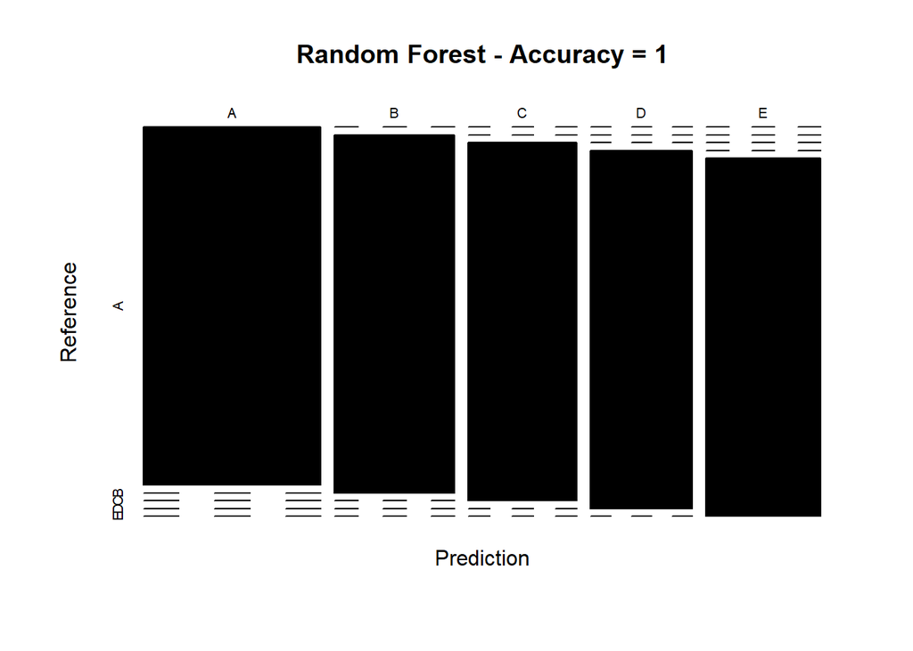

```r
plot(confustionmatrix1$table, col = confustionmatrix1$byClass,
     main = paste("Random Forest - Accuracy =",
                  round(confustionmatrix1$overall['Accuracy'], 4)))
```

```r
prediction2 <- predict(model1, validation)
confustionmatrix2 <- confusionMatrix(prediction2, validation$classe)
confustionmatrix2
```

```
## Confusion Matrix and Statistics
##
##           Reference
## Prediction    A    B    C    D    E
##          A 1176    0    0    0    0
##          B    0  799    0    0    0
##          C    0    0  711    0    0
##          D    0    0    0  679    0
##          E    0    0    0    0  759
##
## Overall Statistics
##
##                Accuracy : 1
##                  95% CI : (0.9991, 1)
##     No Information Rate : 0.2852
##     P-Value [Acc > NIR] : < 2.2e-16
##
##                   Kappa : 1
##  Mcnemar's Test P-Value : NA
##
## Statistics by Class:
##
##                      Class: A Class: B Class: C Class: D Class: E
## Sensitivity            1.0000   1.0000   1.0000   1.0000    1.000
## Specificity            1.0000   1.0000   1.0000   1.0000    1.000
## Pos Pred Value         1.0000   1.0000   1.0000   1.0000    1.000
## Neg Pred Value         1.0000   1.0000   1.0000   1.0000    1.000
## Prevalence             0.2852   0.1937   0.1724   0.1646    0.184
## Detection Rate         0.2852   0.1937   0.1724   0.1646    0.184
## Detection Prevalence   0.2852   0.1937   0.1724   0.1646    0.184
## Balanced Accuracy      1.0000   1.0000   1.0000   1.0000    1.000
```

And, we will plot the matrix results again:

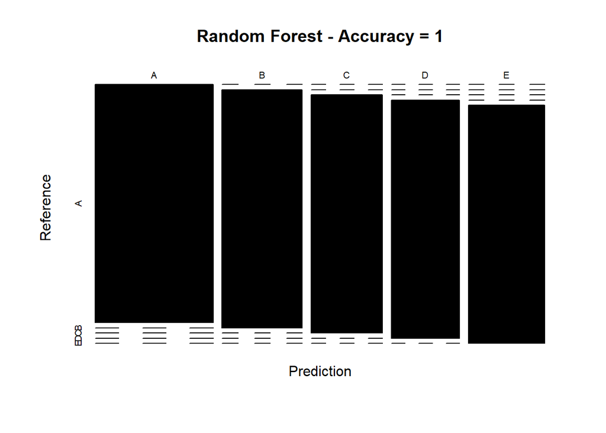

```r
plot(confustionmatrix2$table, col = confustionmatrix2$byClass,
     main = paste("Random Forest - Accuracy =",
                  round(confustionmatrix2$overall['Accuracy'], 4)))
```

As well, we will take a look at the decision tree

```r
set.seed(1234)
library(rpart)
```

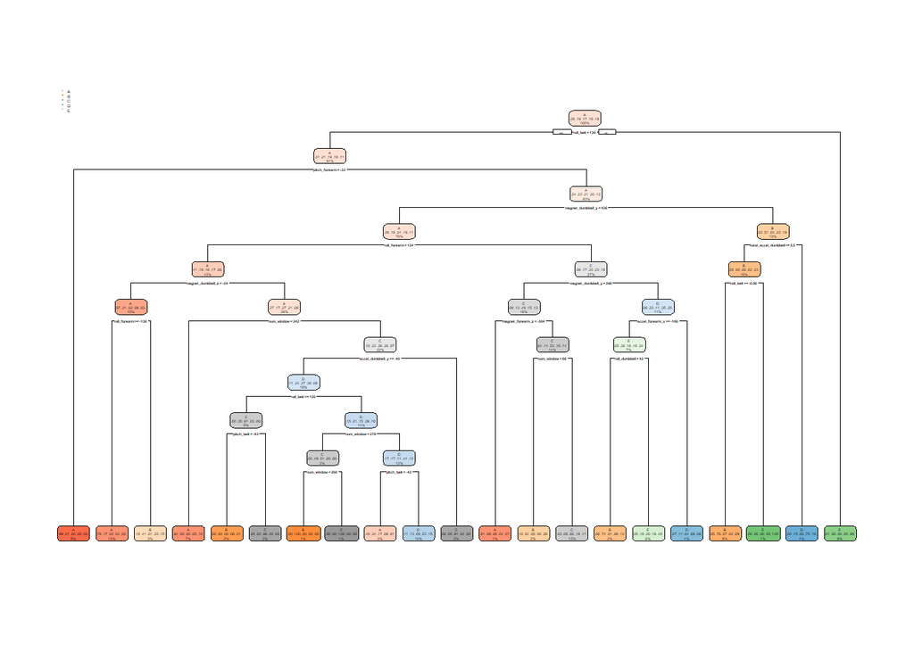

```r
library(rpart.plot)
DecTree <- rpart(classe ~., data = training, method="class")
rpart.plot(DecTree)
```

# COnclusion

## Testing the model

We will use the same feature selection method as before:

```r
testing <- testing[, colSums(is.na(testing)) == 0]
testing <- testing[, -(1:5)]
nzvt <- nearZeroVar(testing)
testing <- testing[, -nzvt]
```

Finally, we will test the random forest test on the test data:

```r
prediction3 <- predict(model1, testing)
prediction3
```

```
##  [1] B A B A A E D B A A B C B A E E A B B B
## Levels: A B C D E
```